# Trabalho Final Disciplina Análise e coleta de Dados

Erica Jordana Bento Viana Cruz

25 de Outubro de 2018

## 1. Objeto: Análise de Dados de atendimentos finalizados do sistema Consumidor.gov em relação ao segmento de mercado de Transporte Aéreo nos anos dde 2015 a 2018.

[figure not shown]

## 2. Contexto e Justificativa: A plataforma Consumidor.gov

O **Consumidor.gov.br** É um serviço público que permite a interlocução direta entre consumidores e empresas para solução alternativa de conflitos de consumo pela internet. Em Janeiro de 2018 completou 1.000.000 de reclamações finalizadas

Ele não substitui o serviço prestado pelos órgãos de Defesa do Consumidor, que continuam atendendo os consumidores normalmente por meio de seus canais tradicionais de atendimento.

A principal inovação do Consumidor.gov.br está em possibilitar uma interlocução direta entre consumidores e empresas, em um ambiente totalmente público e transparente, dispensada a intervenção do Poder Público na tratativa individual.

**Em dezembro de 2016, a Agência Nacional de Aviação Civil – ANAC e a Secretaria Nacional do Consumidor – Senacon do Ministério da Justiça, assinaram o Acordo de Cooperação Técnica nº 2, pelo qual a ANAC aderiu à plataforma de solução alternativa de conflitos Consumidor.gov.br.**

O Consumidor.gov.br é gerido pela Senacon, em conjunto com outros órgãos públicos de defesa do consumidor. O uso da plataforma é recomendado pelo Poder Judiciário de 16 Estados como forma de promoção de conciliação e redução da judicialização. O sistema ainda foi reconhecido pelo Ministério da Transparência e Controladoria Geral da União como melhor serviço público digital do Governo Federal.

Com a adesão da ANAC, a agência reguladora passa a realizar um monitoramento de maior qualidade sobre as reclamações de consumidores em relação ao serviço de transporte aéreo de passageiros. A parceria visa otimizar a utilização de um canal público de solução alternativa de conflitos, propiciando resolução célere e segura de conflitos de consumo. A representatividade do transporte aéreo na plataforma em 2017 é de 2,51% das reclamações registradas, segundo divulgação da Senacon.

**Entender as reclamações e como os envolvidos se comportam, auxilia na melhor definição de políticas públicas para as relações de consumo no setor.**

**Mais informações podem ser obtidas no website do Consumidor.gov] (http:\\www.consumidor.gov.br) .**

## 3. Objetivos: Perguntas de Pesquisa

#### 3.1 A quantidade de reclamações por segmento de mercado de Transporte é relevante em relação ao total de reclamações?

#### 3.2 Quais são as 3 empresas com mais reclamações?

#### 3.3 Como está o uso do consumidor.gov para o segmento de transporte áereo nos anos analisados?

#### 3.4 Como se dá o encerramento das reclamações, são resolvidas?

## 4. Método: Como foram coletados, tratados e organizados os dados

Os dados a serem trabalhados foram obtidos no site do consumidor.gov.br em formato .csv e tratados conforme abaixo.

4.1 Carregando o arquivo em mémoria e depois vamos usar o bind e apagar os arquivos temporários.

```r
setwd("G:/ENAP_Espe/D6_ColEAnDados/D6_ExercFinal_EricaJordana/dados_brutos/")
consumidorgov1 <- read.csv ("2015_1.csv",head=TRUE, sep = ";")
consumidorgov2 <- read.csv ("2015_2.csv",head=TRUE, sep = ";")
consumidorgov3 <- read.csv ("2016_1.csv",head=TRUE, sep = ";")
consumidorgov4 <- read.csv ("2016_2.csv",head=TRUE, sep = ";")
consumidorgov5 <- read.csv ("2017_1.csv",head=TRUE, sep = ";")
consumidorgov6 <- read.csv ("2017_2.csv",head=TRUE, sep = ";")
consumidorgov181 <- read.csv ("2018-01.csv",head=TRUE, sep = ";")
consumidorgov182 <- read.csv ("2018-02.csv",head=TRUE, sep = ";")
consumidorgov183 <- read.csv ("2018-03.csv",head=TRUE, sep = ";")
consumidorgov184 <- read.csv ("2018-04.csv",head=TRUE, sep = ";")
consumidorgov185 <- read.csv ("2018-05.csv",head=TRUE, sep = ";")
consumidorgov186 <- read.csv ("2018-06.csv",head=TRUE, sep = ";")
consumidorgov187 <- read.csv ("2018-07.csv",head=TRUE, sep = ";")
consumidorgov188 <- read.csv ("2018-08.csv",head=TRUE, sep = ";")
consumidorgov189 <- read.csv ("2018-09.csv",head=TRUE, sep = ";")
```

## 4.2 Tratamento dos dados: agrupando os dados em um único arquivo.

```r
## Usando bind para agrupar todos os arquivos em um único arquivo.
consumidorgov <- bind_rows(consumidorgov1,consumidorgov2,consumidorgov3,consumidorgov4,consumidorgov5,consumidorgov6,consumidorgov181,consumidorgov182,consumidorgov183,consumidorgov184,consumidorgov185,consumidorgov186,consumidorgov187,consumidorgov188,consumidorgov189)

## removendo arquivos temporários
rm(consumidorgov1,consumidorgov2,consumidorgov3,consumidorgov4,consumidorgov5,consumidorgov6,consumidorgov181,consumidorgov182,consumidorgov183,consumidorgov184,consumidorgov185,consumidorgov186,consumidorgov187,consumidorgov188,consumidorgov189)
```

## 4.3 Tratamento dos dados: organizando as colunas.

```r
##Limpando os dados das colunas usando o pacote janitor.
consumidorgov <- consumidorgov %>% clean_names()

names(consumidorgov)[10] <- "Area"
names(consumidorgov)[1]  <- "Regiao"
names(consumidorgov)[5]  <- "Faixa_Etaria"
names(consumidorgov)[6]  <- "Data_Finalizacao"
names(consumidorgov)[17] <- "Situacao"
names(consumidorgov)[18] <- "Avaliacao_Reclamacao"
names(consumidorgov)[8]  <- "Nome_Fantasia"
names(consumidorgov)[9]  <- "Segmento_Mercado"
names(consumidorgov)[19] <- "Nota_Consumidor"
names(consumidorgov)[15] <- "Procurou_Empresa"
names(consumidorgov)[14] <- "Como_Contratou"
names(consumidorgov)[12] <- "Grupo_Problema"
names(consumidorgov)[7]  <- "Tempo_Resposta"

colnames(consumidorgov)
```

```
##  [1] "Regiao"               "uf"                   "cidade"
##  [4] "sexo"                 "Faixa_Etaria"         "Data_Finalizacao"
##  [7] "Tempo_Resposta"       "Nome_Fantasia"        "Segmento_Mercado"
## [10] "Area"                 "assunto"              "Grupo_Problema"
## [13] "problema"             "Como_Contratou"       "Procurou_Empresa"
## [16] "respondida"           "Situacao"             "Avaliacao_Reclamacao"
## [19] "Nota_Consumidor"      "total"
```

## 4.4 Tratamento de dados: Criando conjuntos de dados usando filter

```r
consumidoraereo <- consumidorgov %>% filter(Segmento_Mercado == "Transporte Aéreo")

## Tabela de Problemas
problemas <- consumidoraereo %>% count(problema)

## Data atualizando
consumidoraereo <- consumidoraereo %>% mutate(Data_Finalizacao = dmy(Data_Finalizacao), ano = year(Data_Finalizacao))

### Tabela de Empresas e ano das reclamações ordenado decrescente pelas que tem mais reclamação
empresas_ano <- consumidoraereo %>% count(Nome_Fantasia, ano, Avaliacao_Reclamacao) %>% arrange(desc(Nome_Fantasia, ano, Avaliacao_Reclamacao, n))

##Analisando dados das 3 principais empresas
##empresas_ano_principais <- empresas_ano %>% filter (Nome_Fantasia %in% c("Tam", "Gol Linhas Aéreas", "Latam Airlines (Tam)", "Azul Linhas Aéreas", "Avianca - Aerovias", "Avianca - Oceanair"))
```

## 5. Qual a proporção de problemas por área

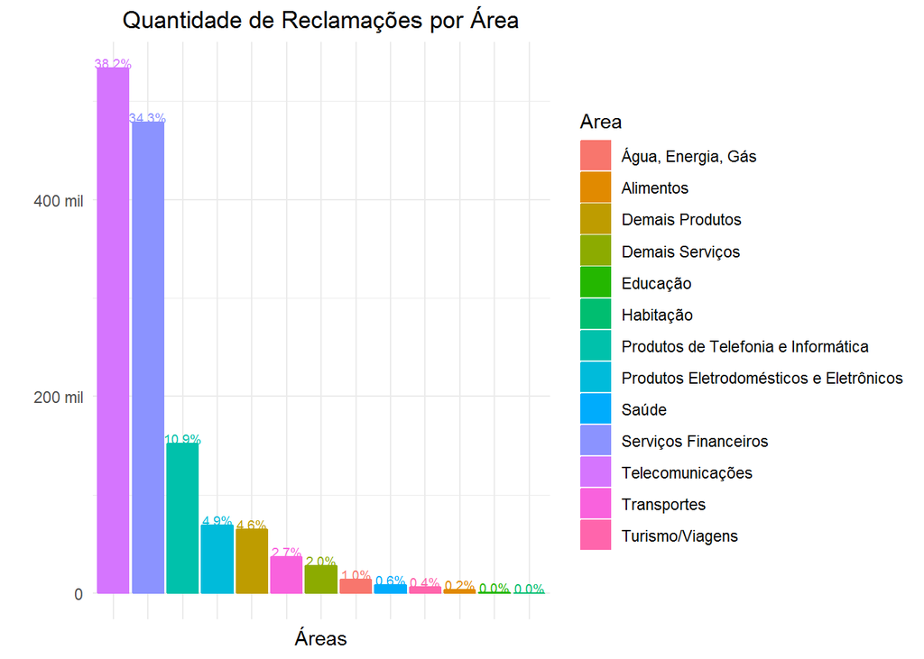

```r
reclamacoes_area <- consumidorgov %>% select(Area) %>% count (Area) %>%
  mutate (prop = n / sum(n), prop = scales::percent(prop))

reclamacoes_area %>% ggplot (aes (x = reorder(Area, -n), y = n, colour = Area, fill = Area)) +
  theme_minimal() +
  geom_bar(stat = 'identity') +
  scale_y_continuous(name = "" , breaks = c(0,2e+05,4e+05),labels=c('0','200 mil','400 mil')) +
  labs(title = "Quantidade de Reclamações por Área", x = "Áreas") +
  theme(axis.text.x = element_blank()) +
  theme(plot.title = element_text(hjust = 0.5), plot.subtitle = element_text(hjust = 0.5)) +
  geom_text( aes(label = prop, y = n + 0.5), position = position_dodge(0.9), vjust = 0, size = 2.5)
```

## 6. Quantidade de reclamações pelas 3 principais empresas

```r
##Quantidade de reclamações por empresas.
reclamacoes_empresas <- consumidoraereo %>% select(Nome_Fantasia) %>% count (Nome_Fantasia) %>% mutate (prop = n / sum(n), prop = scales::percent(prop))

##Separando as principais empresas
(reclamacoes_empresa <- reclamacoes_empresas %>% filter (Nome_Fantasia %in% c("Tam", "Gol Linhas Aéreas", "Latam Airlines (Tam)", "Azul Linhas Aéreas", "Avianca - Aerovias", "Avianca - Oceanair")) %>% arrange(desc(n)))
```

```
## # A tibble: 6 x 3
##   Nome_Fantasia            n prop
##   <chr>                <int> <chr>
## 1 Latam Airlines (Tam) 16145 40.8%
## 2 Azul Linhas Aéreas    8370 21.2%
## 3 Gol Linhas Aéreas     7518 19.0%
## 4 Avianca - Oceanair    3741 9.5%
## 5 Tam                   1552 3.9%
## 6 Avianca - Aerovias     810 2.0%
```

[figure not shown]

```r
##Quantidade de reclamações por empresas.
reclamacoes_empresa %>% ggplot (aes (x= "", y = prop, fill = Nome_Fantasia)) +
    theme_minimal() +
    geom_bar (stat = "identity") +
    labs(title = "Quantidade de reclamações pelas principais empresas", x = "", y="", fill = "Empresas") +
    coord_polar("y", start = 0) +
    scale_fill_viridis_d() +
    theme(plot.title = element_text(hjust = 0.5), plot.subtitle = element_text(hjust = 0.5))
```

## 7. Quantidade de reclamações por ano no segmento de transporte áereo

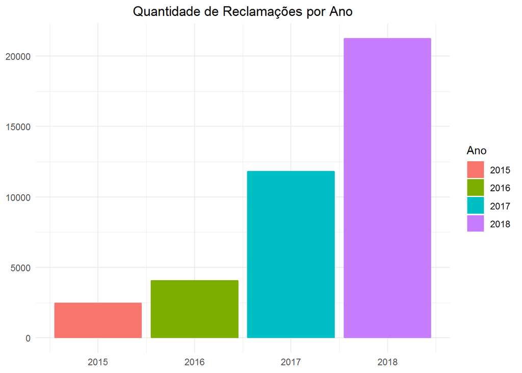

```r
consumidoraereo %>% ggplot (aes (x = ano, colour = as.factor(ano) , fill = as.factor(ano))) +
    theme_minimal() +
    geom_bar(stat = 'count') +
    labs(title = "Quantidade de Reclamações por Ano", fill = "Ano", y = "" ) +
    theme(axis.title.y = element_blank(), axis.title.x = element_blank()) +
    theme(plot.title = element_text(hjust = 0.5), plot.subtitle = element_text(hjust = 0.5)) +
    guides (colour = FALSE)
```

## 8. Avaliação das reclamações finalizadas

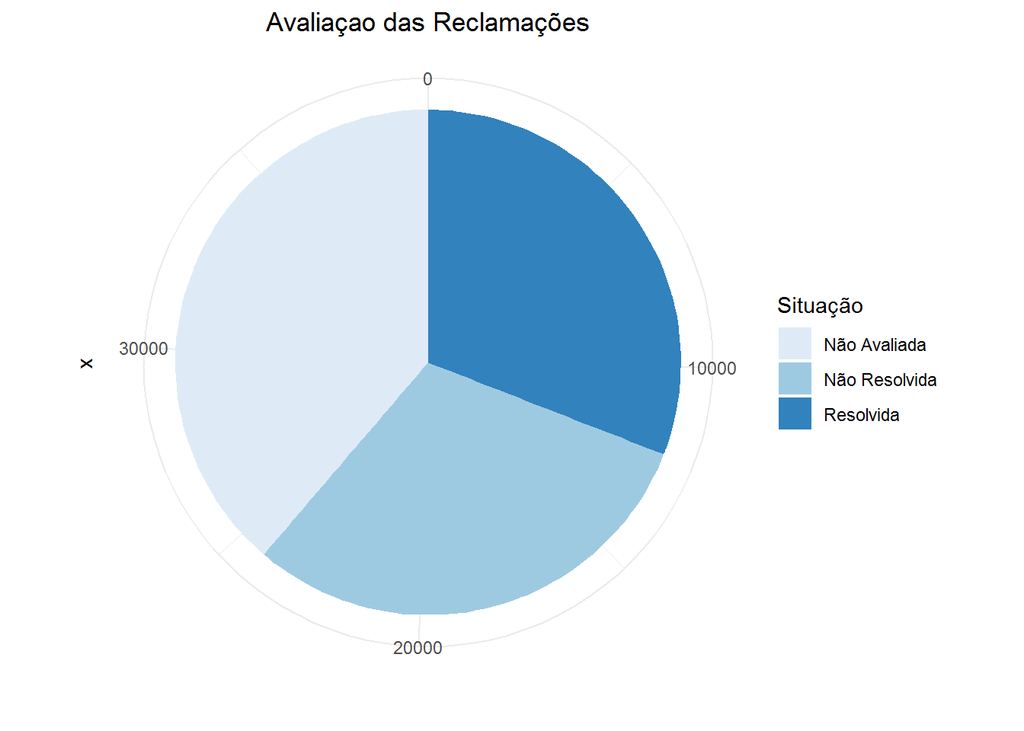

```r
empresas_ano %>% ggplot (aes (x= "", y = n , fill = Avaliacao_Reclamacao)) +
    theme_minimal() +
    geom_bar (stat = "identity") +
    labs(title = "Avaliaçao das Reclamações", fill = "Situação", y = "") +
    coord_polar("y", start = 0) +
    scale_fill_brewer(palette = "Blues") +
    theme(plot.title = element_text(hjust = 0.5), plot.subtitle = element_text(hjust = 0.5))
```

## 9. Conclusões

9.1 A quantidade de reclamações no setor de Transportes é cerca de 2,7% conforme o primeiro gráfico. Portanto bastante baixa em relação ao segmento de serviços financeiros.

9.3 Em relação aos anos há um crescimento substanial no quantitativo de reclamações, possivelmente por uma maior divulgação da solução para os cidadãos e da resolução rápida de reclamações.

9.4 Cerca de 30% das reclamações são declaradas resolvidas.